# 99_checks.R

steffi

2021-02-10

Copyright 2021 Province of British Columbia

Licensed under the Apache License, Version 2.0 (the “License”); you may not use this file except in compliance with the License. You may obtain a copy of the License at

http://www.apache.org/licenses/LICENSE-2.0

Unless required by applicable law or agreed to in writing, software distributed under the License is distributed on an “AS IS” BASIS, WITHOUT WARRANTIES OR CONDITIONS OF ANY KIND, either express or implied. See the License for the specific language governing permissions and limitations under the License.

> Render this file with:

> rmarkdown::render(input = “99_checks.R”, output_dir = “share”)

## Preamble

This file checks that the `st_difference()` actually correctly removed overlapping areas in `02_clean.R`. It also establishes that there are some overlaps, which when removed leave little wiggly bits left over.

These could be

1. ignored
2. fixed by using something like st_snap before st_difference
3. removed manually

## Load packages

```r
library(tidyverse)
library(sf)
library(patchwork)
```

## Load protected areas

```r
pa1 <- read_rds("data/CPCAD_Dec2019_BC_clean.rds")
pa2 <- read_rds("data/CPCAD_Dec2019_BC_clean_no_ovlps.rds") %>%
  mutate(area2 = as.numeric(st_area(Shape)))
```

pa1 = original clean, pa2 with overlaps removed

```r
pa2_df <- st_set_geometry(pa2, NULL) %>%
  group_by(zone_id, name_e) %>%
  summarize(area1 = unique(area1), area2 = sum(area2))
```

Look for features where a lot of overlap was removed

```r
filter(pa2_df, abs(area1 - area2) > 5000000)
```

```
## # A tibble: 3 x 4
## # Groups:   zone_id [3]
##     zone_id name_e                              area1         area2
##       <dbl> <chr>                               <dbl>         <dbl>
## 1 591000446 Myra - Bellevue Park            77881251.        0.0452
## 2 592000250 Cape Scott Park                 51942277. 19456910.
## 3 730003200 Columbia National Wildlife Area 10018781.  4620729.
```

## Myra - Bellevue Park

```r
bbx <- filter(pa2, str_detect(name_e, "Myra")) %>%
  st_buffer(dist = 1000) %>%
  st_bbox()

sub_pa1 <- st_crop(pa1, bbx)
sub_pa2 <- sub_pa1 %>%
  select(zone_id, name_e, oecm, iucn_cat, protdate) %>%
  arrange(oecm, iucn_cat, protdate) %>%
  st_difference()

sub_pa2
```

```
## Simple feature collection with 2 features and 5 fields
## geometry type:  MULTIPOLYGON
## dimension:      XY
## bbox:           xmin: -1656061 ymin: 1350467 xmax: -1645356 ymax: 1366948
## projected CRS:  Canada_Albers_Equal_Area_Conic
##     zone_id                       name_e oecm iucn_cat protdate                          Shape
## 1 591000446         Myra - Bellevue Park   No       II     2001 MULTIPOLYGON (((-1651358 13...
## 2 591005024 Myra-Bellevue Protected Area   No      N/A     2007 MULTIPOLYGON (((-1654332 13...
```

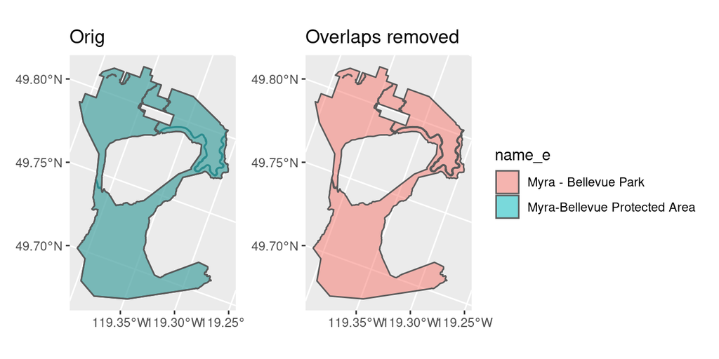

```r
g1 <- ggplot(data = sub_pa1, aes(fill = name_e)) +
  geom_sf(alpha = 0.5) + labs(title = "Orig")
g2 <- ggplot(data = sub_pa2, aes(fill = name_e)) +
  geom_sf(alpha = 0.5) + labs(title = "Overlaps removed")
g1 + g2 + plot_layout(guides = "collect")
```

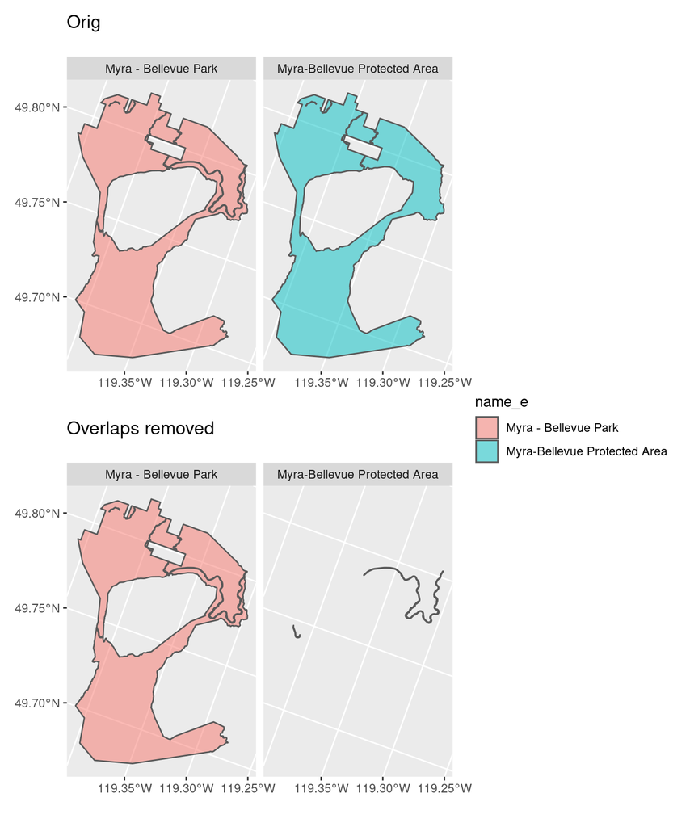

```r
(g1 + facet_wrap(~name_e)) / (g2 + facet_wrap(~name_e)) +
  plot_layout(guides = "collect")
```

Good, no problems, Myra-Vellevue Protected Area includes river, but Myra - Bellevue Park is the rest

## Cape Scott Park

```r
bbx <- filter(pa2, zone_id == 592000250) %>%
  st_buffer(dist = 1000) %>%
  st_bbox()

sub_pa1 <- st_crop(pa1, bbx)
sub_pa2 <- sub_pa1 %>%
  select(zone_id, name_e, oecm, iucn_cat, protdate) %>%
  arrange(oecm, iucn_cat, protdate) %>%
  st_difference()
```

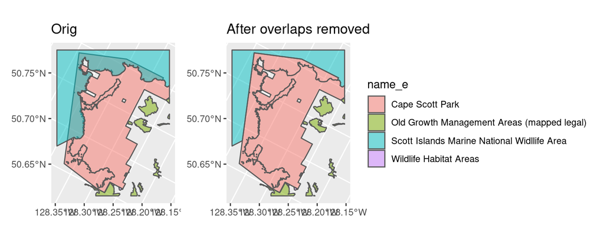

```r
g1 <- ggplot(data = sub_pa1, aes(fill = name_e)) +
  geom_sf(alpha = 0.5) + labs(title = "Orig")
g2 <- ggplot(data = sub_pa2, aes(fill = name_e)) +
  geom_sf(alpha = 0.5) + labs(title = "After overlaps removed")
g1 + g2 + plot_layout(guides = "collect")
```

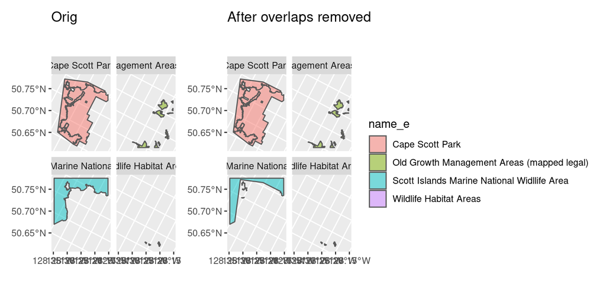

```r
g1 + facet_wrap(~name_e) +
  g2 + facet_wrap(~name_e) +
  plot_layout(guides = "collect")
```

Check out wiggly bits left over

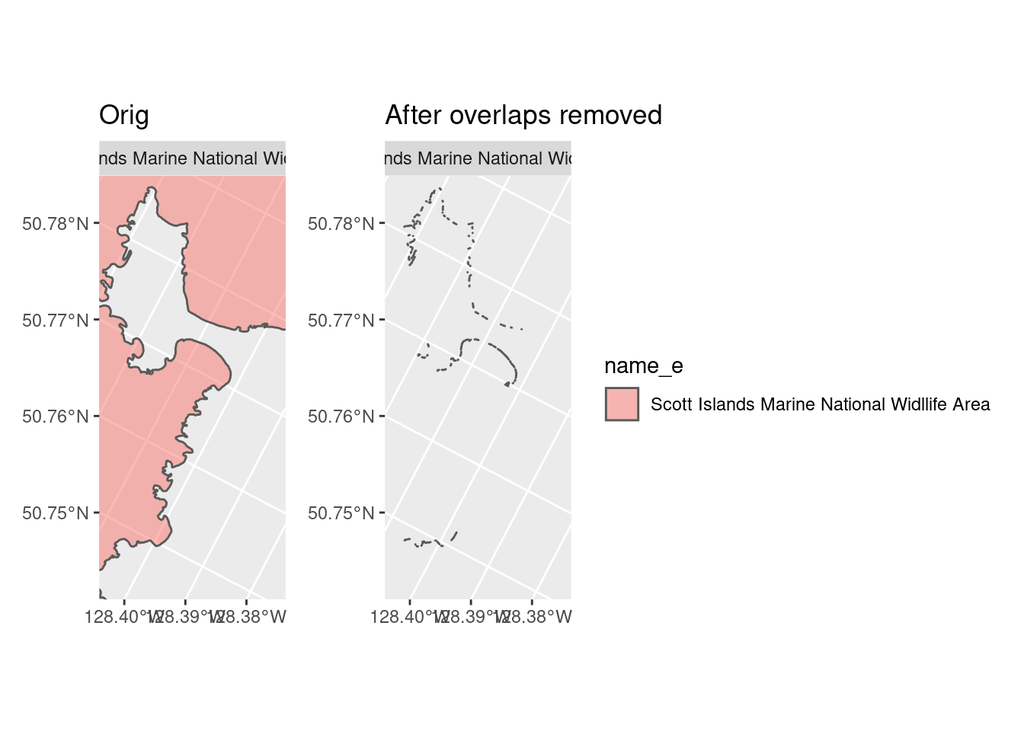

```r
g1 <- ggplot(data = filter(sub_pa1, zone_id == 730017000), aes(fill = name_e)) +
  geom_sf(alpha = 0.5) +
  coord_sf(xlim = c(-2195800, -2193595), ylim = c(1718783, 1723805)) +
  facet_wrap(~name_e) +
  labs(title = "Orig")
g2 <- ggplot(data = filter(sub_pa2, zone_id == 730017000), aes(fill = name_e)) +
  geom_sf(alpha = 0.5) +
  coord_sf(xlim = c(-2195800, -2193595), ylim = c(1718783, 1723805)) +
  facet_wrap(~name_e)+
  labs(title = "After overlaps removed")

g1 + g2 + plot_layout(guides = "collect")
```

```r
sub_pa2 %>%
  filter(zone_id == 730017000) %>%
  st_crop(c(xmin =-2195800, xmax = -2193595,
            ymin = 1718783, ymax = 1723805)) %>%
  st_area() %>%
  sum()
```

```
## 2330.514 [m^2]
```

Left over bits add 2330 m^2 or 0.233 hectares to Scott islands Marine National Wildlife Area

```r
filter(pa2, str_detect(name_e, "Scott Islands")) %>%
  pull(area2) %>%
  sum()
```

```
## [1] 11568359714
```

Minuscule error (if this is the total amount)

## Columbia National Wildlife Area

```r
bbx <- filter(pa2, zone_id == 730003200) %>%
  st_buffer(dist = 1000) %>%
  st_bbox()

sub_pa1 <- st_crop(pa1, bbx)
sub_pa2 <- st_crop(pa2, bbx)
sub_pa2 %>% select(zone_id, name_e, oecm, iucn_cat, protdate)
```

```
## Simple feature collection with 37 features and 5 fields
## geometry type:  GEOMETRY
## dimension:      XY
## bbox:           xmin: -1410853 ymin: 1365344 xmax: -1396383 ymax: 1418662
## projected CRS:  Canada_Albers_Equal_Area_Conic
## First 10 features:
##         zone_id                        name_e oecm iucn_cat protdate                          Shape
## 246   591404002    Columbia NWA - Brisco Unit   No      Yes     1979 POLYGON ((-1405262 1399624,...
## 246.1 591404002    Columbia NWA - Brisco Unit   No      Yes     1979 POLYGON ((-1404914 1399881,...
## 247   591404004    Columbia NWA - Brisco Unit   No      Yes     1979 POLYGON ((-1404949 1401853,...
## 247.1 591404004    Columbia NWA - Brisco Unit   No      Yes     1979 POLYGON ((-1405316 1402292,...
## 254   591404100 Columbia NWA - Harrogate Unit   No      Yes     1980 POLYGON ((-1409188 1414564,...
## 254.1 591404100 Columbia NWA - Harrogate Unit   No      Yes     1980 POLYGON ((-1408977 1414502,...
## 254.2 591404100 Columbia NWA - Harrogate Unit   No      Yes     1980 POLYGON ((-1409404 1415646,...
## 254.3 591404100 Columbia NWA - Harrogate Unit   No      Yes     1980 POLYGON ((-1409745 1416467,...
## 255   591403601   Columbia River - RCMP Flats   No      Yes     1980 POLYGON ((-1400102 1386482,...
## 255.1 591403601   Columbia River - RCMP Flats   No      Yes     1980 POLYGON ((-1401417 1386727,...
```

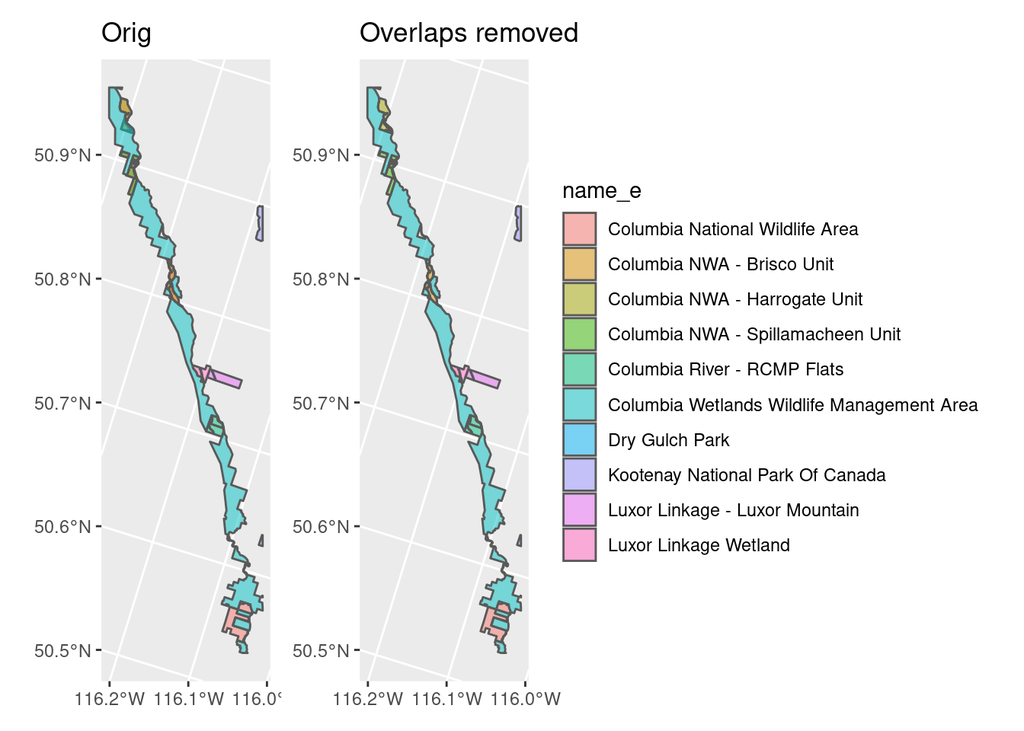

```r
g1 <- ggplot(data = sub_pa1, aes(fill = name_e)) +
  geom_sf(alpha = 0.5) + labs(title = "Orig")
g2 <- ggplot(data = sub_pa2, aes(fill = name_e)) +
  geom_sf(alpha = 0.5) + labs(title = "Overlaps removed")
g1 + g2 + plot_layout(guides = "collect")
```

```r
bbx2 <- c(bbx[1], bbx[2] + 40000, bbx[3]-10000, bbx[4])
sub_pa1 <- st_crop(pa1, bbx2)
sub_pa2 <- st_crop(pa2, bbx2)
```

```r
g1 <- ggplot(data = sub_pa1, aes(fill = name_e)) +
  geom_sf(alpha = 0.5) + labs(title = "Orig")
g2 <- ggplot(data = sub_pa2, aes(fill = name_e)) +
  geom_sf(alpha = 0.5) + labs(title = "Overlaps removed")

g11 <- ggplot(data = sub_pa1, aes(fill = name_e)) +
  geom_sf(alpha = 0.5) + labs(title = "Orig") +
  facet_wrap(~name_e, nrow = 1)
g22 <- ggplot(data = sub_pa2, aes(fill = name_e)) +
  geom_sf(alpha = 0.5) + labs(title = "Overlaps removed") +
  facet_wrap(~name_e, nrow = 1)
```

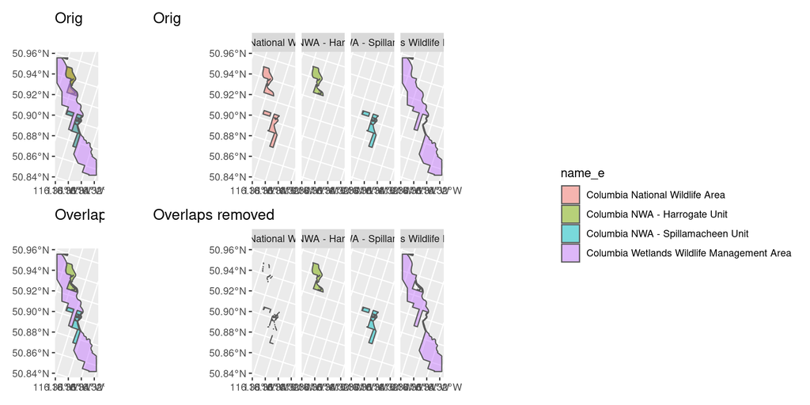

```r
(g1 + g11) / (g2 + g22) + plot_layout(guides = "collect")
```

```r
filter(sub_pa2, name_e == "Columbia National Wildlife Area") %>%
  pull(area2) %>%
  sum()
```

```
## [1] 83229.88
```

83229.88 m^2 or 8.322 hectares left over…

```r
filter(pa2, name_e == "Columbia National Wildlife Area") %>%
  pull(area2) %>%
  sum()
```

```
## [1] 4620729
```

4620729 m^2 or 462.0729 hectares remaining total

Therefore 1.8% error in this case…